[figure not shown]

# PyData Southampton News, May 2024

### 7th Meetup, hosted by Carnival UK

### @PyDataSoton

# PyData Code of Conduct

### https://pydata.org/code-of-conduct/

[interactive chart not shown]

# NumFOCUS

- US-based charity in support of open-source scientific computing
- Financial and admin support for many open-source projects
- Support for many community events
- https://numfocus.org

[interactive chart not shown]

# PyData

- Educational program by NumFOCUS
- A global community
- 230 groups (+3 this year) across 80 countries world-wide
- 236,041+ users world-wide (+23,000 per year!)
- https://www.meetup.com/pro/pydata/

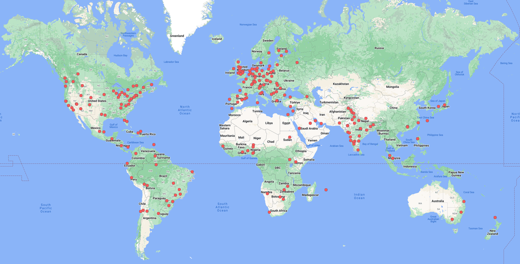

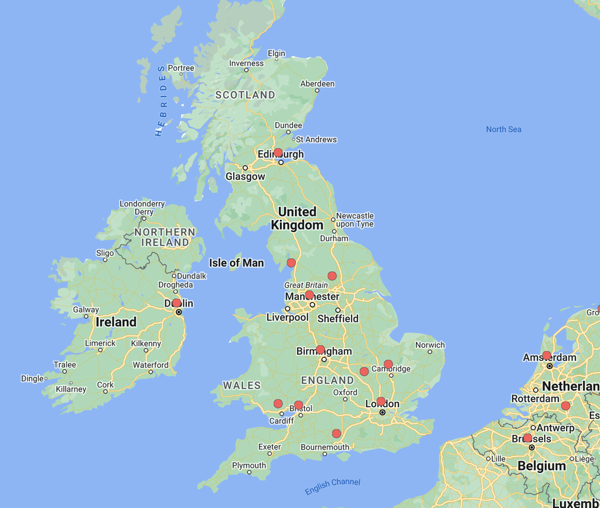

# PyData Southampton

- 430 members (+20! Tell a friend! Submit a talk! Always need a ⚡)
- Monthly meetup
- All run by volunteers
- Propose a Talk: https://bit.ly/pydataSoton-talks

[figure not shown]

1. The operating company for P&O Cruises & Cunard; no one knows cruising like Carnival UK!
2. Sponsors **PyData Southampton** ❤️❤️❤️

# Upcoming Conferences

### Courtesy of https://pythondeadlin.es/

#### 🇬🇧 Jun 14-16 2024 - PyData London Conference 🚨 Tickets selling fast 🚨

- **Sponsorship slots still open; great exposure for your employer!!!**

#### 🇳🇱 Sep 18-20 2024 - PyData Amsterdam Conference 🚨 CFP open, June 2nd 🚨

#### 🇫🇷 Sep 25-26 2024 - PyData Paris Conference 🚨 CFP closed 🚨

[interactive chart not shown]

[figure not shown]

# Package of the Month (POTM)

## Ollama - https://ollama.com/

[figure not shown]

# Tonight's Schedule

#### 18:30 Doors open

#### 19:00 Talks start ⬅️ **YOU ARE HERE**

#### 19:15 Retrieval Augmented Generation Workshop

#### Break 🥂

#### 20:45 to 21:00 We're done 🔜 All Bar One 🍻

### Retrieval Augmented Generation Workshop - Dan Gibson

Join us for an interactive workshop focused on building RAG (Retrieval Augmented Generation) Chat applications! Whether you're new to Python or a seasoned pro, this hands-on session is designed to be inclusive for all skill levels.

What to Expect: Introduction:

Discover what Retrieval Augmented Generation (RAG) is all about. Explore real-world applications and learn about typical RAG architectures. Learn and Build:

Dive into injecting context into Large Language Models like Chat GPT. Elevate your search and retrieval techniques with Vector indexes. Bring it all together as you create your first RAG bot. Wrap Up:

Summarise key takeaways from the workshop. Explore opportunities to further develop your skills in RAG. All activities will be conducted in Python, and temporary keys and endpoints will be provided during the session to facilitate bot building. Don't miss out on this opportunity to gain practical experience and kickstart your journey into RAG development!

Instructions to prepare in advance To make things as smooth as possible we have prepared some instructions to setup an environment and register for some external services to participate in the workshop. The code and instructions are available on the PyData Southampton github here: https://github.com/PyDataSouthampton/rag_intro_workshop

Please follow the instructions in advance of attending the workshop next week; we will add the exercise code and instructions closer to the event. Note that to fully participate in the workshop you will need accounts with OpenAI and Pinecone; they are free to setup and if you are a new user you get some free credits. Full instructions are on the github repo.

## 🕊️ Tweet/Thread #pydatasoton and @pydatasoton 🦆